# Now, `paper`, `ink` and `accent` arguments and `geom_*()`s that are responsive to theming give ggplots even more sparkle.

And notes for using extensions that haven’t adopted the dynamic `geom_*` theming.

Evangeline Reynolds

2025-06-12

TLDR: The next release of ggplot2 theming is something to be excited for!

A ton of value is delivered to analysts in the form of not needed to worry about fiddly details when it comes to adhering to brand theme – enabling more focus on analysis and interpretation.

To that end two major inovations are coming to ggplot2 theming!

1. new arguments to convenience themes…

and

Now, geom_ and stat_ layers should automatically take on the look and feel of your theme!

And ggplot2 theme convenience functions expose new arguments `paper`, `ink`, and even `accent` (geom_smooth’s color) so changing the look and feel of your plot has never been easier.

```r
knitr::include_graphics("new-theme.png")
```

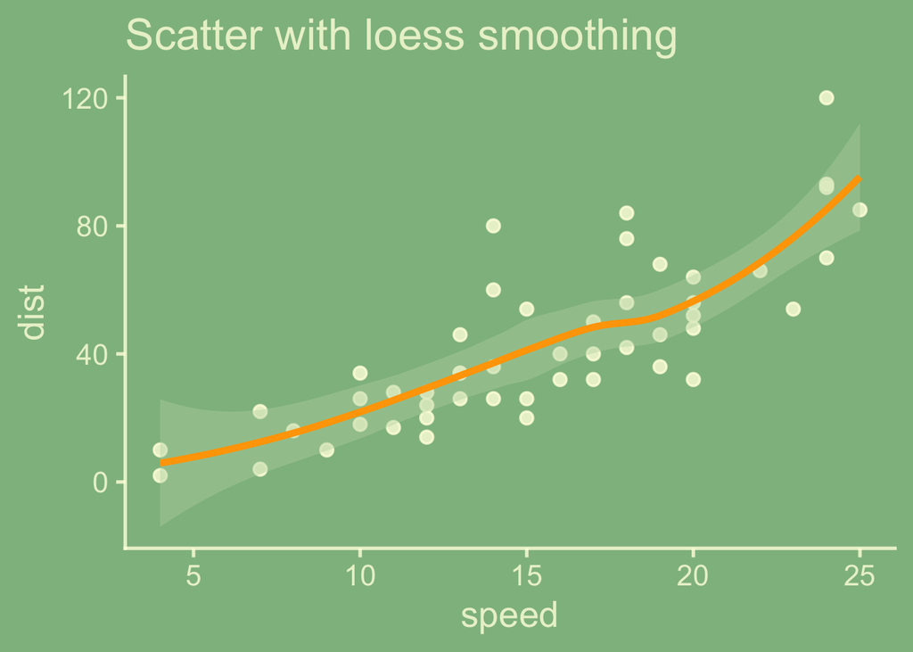

```r
library(tidyverse)


brand_theme1 <- theme_classic(base_size = 20,
         paper = "darkseagreen",
         ink = alpha("lightyellow", .8),
         accent = "orange")

brand_theme2 <- theme_grey(base_size = 10,
         paper = "grey20",
         ink = alpha("whitesmoke", .8),
         accent = "magenta3")


# setting a theme, and plotting
theme_set(brand_theme1)

ggplot(data = cars) +
  aes(x = speed, y = dist) +
  geom_point() +
  geom_smooth() +
  labs(title = "Scatter with loess smoothing")
```

[figure not shown]

```r
# setting a new theme, and plotting
theme_set(brand_theme2)

ggplot(data = cars) +
  aes(x = speed, y = dist) +
  geom_point() +
  geom_smooth() +
  labs(title = "Scatter with loess smoothing")
```

# Uh-oh, what if my favorite geom_*() extension isn’t up-to-date with geom theming?

One unfortunate downside is that layer extensions that involve the creation of new Geom ggproto objects, with new default_aes defined are likely to fail to shine as brightly amid the glamour that the new changes bring.

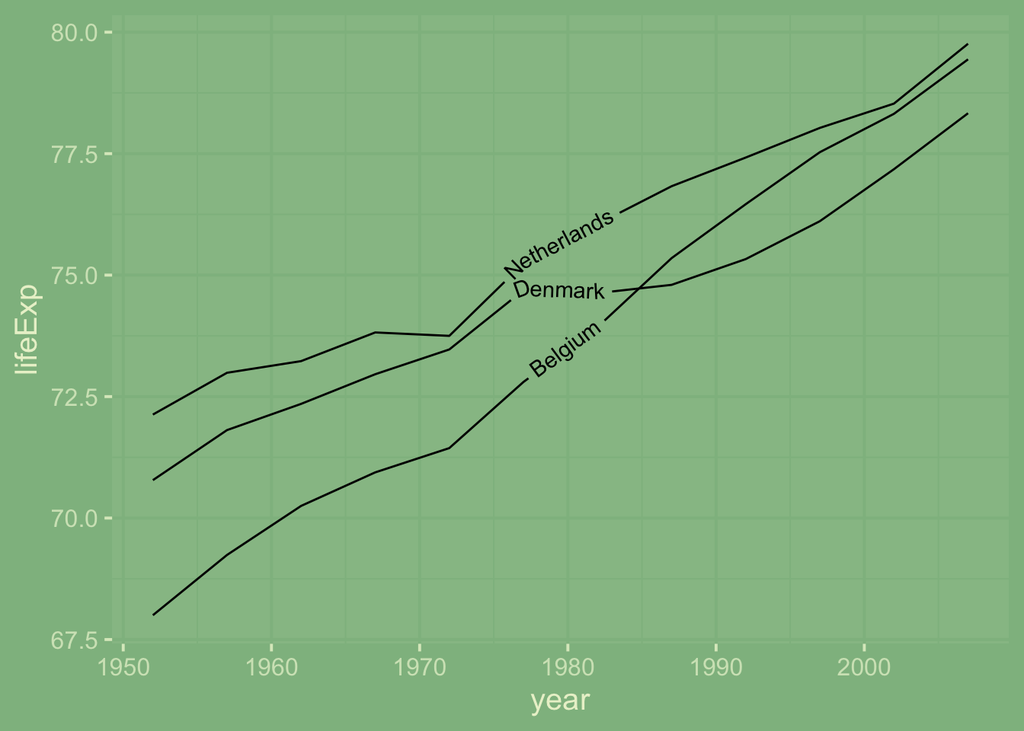

```r
library(tidyverse)
theme_grey(base_size = 15,
         paper = "darkseagreen",
         ink = alpha("lightyellow", .8),
         accent = "orange") |>
  theme_set()

gapminder::gapminder |>
  filter(country %in% c("Netherlands",
                        "Belgium",
                        "Denmark")) |>
  ggplot() +
  aes(x = year,
      y = lifeExp,
      label = country) +
  geomtextpath::geom_textpath()
```

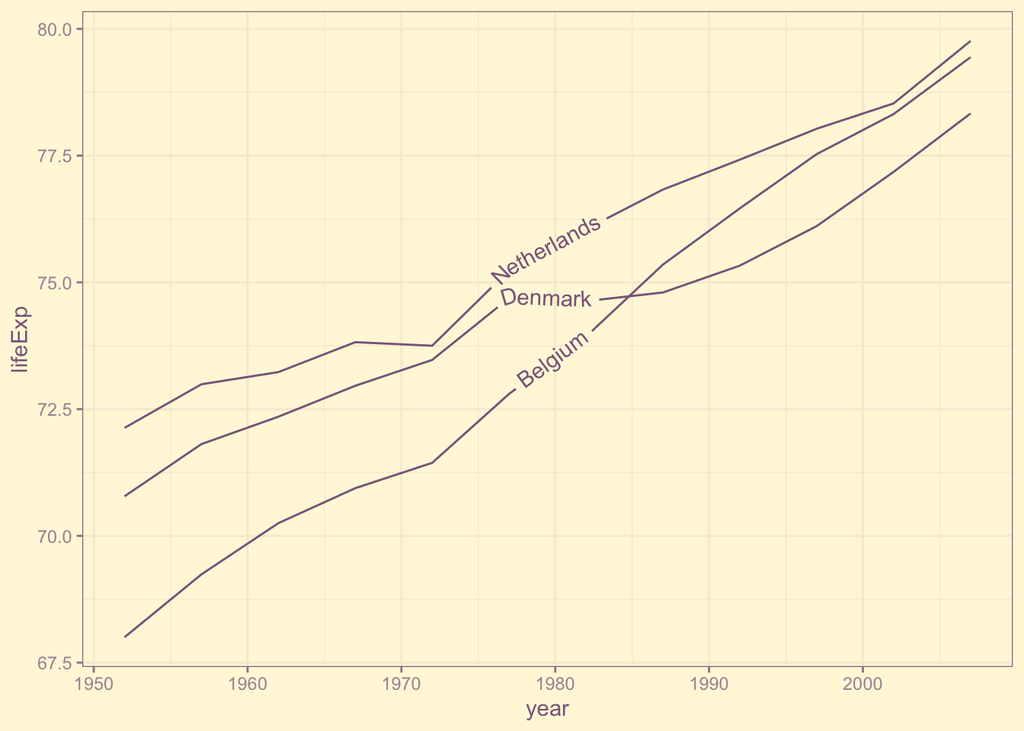

```r
library(tidyverse)

theme_bw(ink = "plum4",
         paper = "cornsilk") |>
  theme_set()

gapminder::gapminder |>
  filter(country %in% c("Netherlands",
                        "Belgium",
                        "Denmark")) |>
  ggplot() +
  aes(x = year,
      y = lifeExp,
      label = country) +
  geomtextpath::geom_textpath(
    color = get_theme()$geom$ink, #<< work around
    )
```

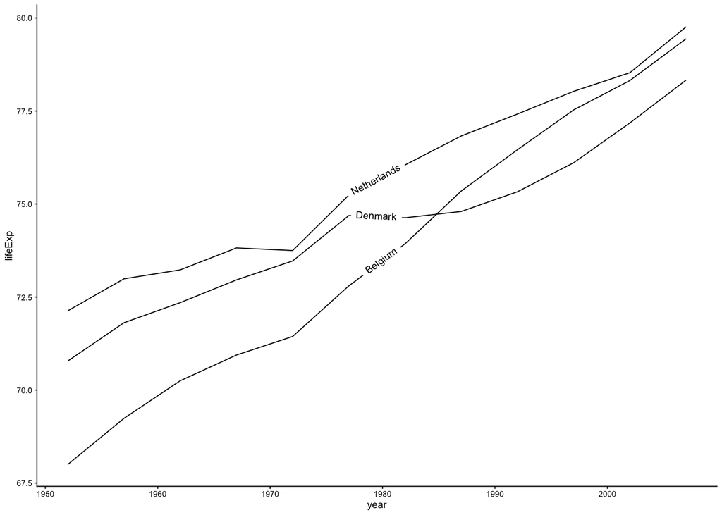

```r
theme_tiny <- theme_classic(base_size = 7)



gapminder::gapminder |>
  filter(country %in% c("Netherlands",
                        "Belgium",
                        "Denmark")) |>
  ggplot() +
  aes(x = year,
      y = lifeExp,
      label = country) +
  geomtextpath::geom_textpath(
    size = theme_tiny$geom$fontsize, #<< work around
    linewidth = theme_tiny$geom$linewidth
    ) +
  theme_tiny
```

Suppose you have created StatChull from the ggplot2 extension vignette, and have also created the modified GeomPolygon

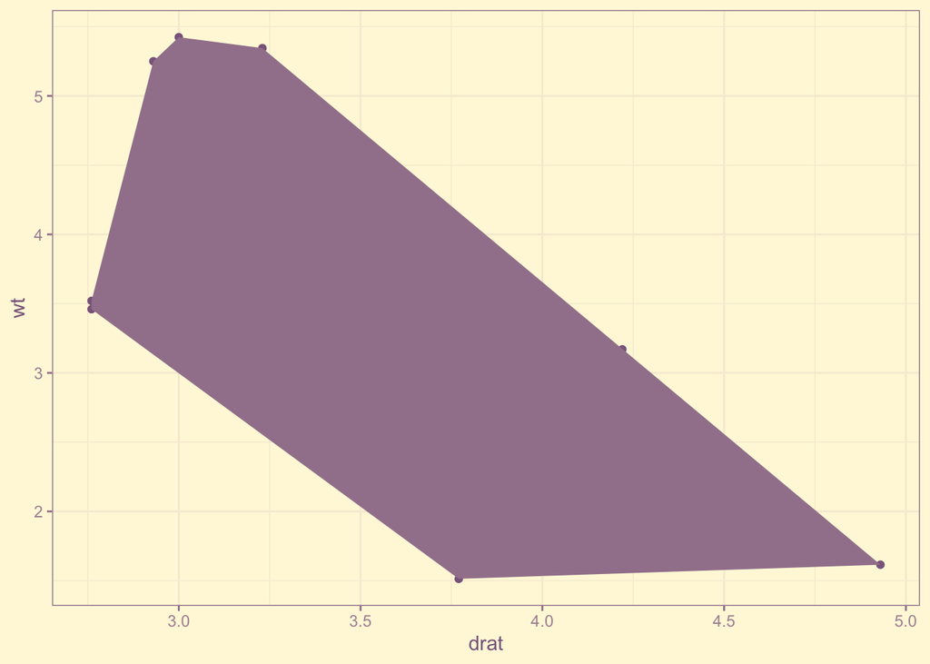

```r
library(dplyr)
compute_group_chull <- function(data, scales){

  chull_indices <- chull(x = data$x, y = data$y)

  data |>
    slice(chull_indices)

}

StatChull <- ggproto(`_class` = "StatChull",
                     `_inherit` = Stat,
                     required_aes = c("x", "y"),
                     compute_group = compute_group_chull)

ggplot(mtcars) +
  aes(x = drat, y = wt) +
  geom_point() +
  geom_polygon(stat = StatChull)
```

# Inherit default aes for Geoms from base ggplot2 Geoms